# Peer-graded Assignment: Milestone Report

Lawrence

11/25/2017

## Introduction

The goal of this project is to create and submit a concise report on R Pubs (http://rpubs.com/) that explains the major features of the data identified from a large corpus document and briefly summarize plans for creating the prediction algorithm and Shiny app in a way that would be understandable to a non-data scientist manager.

The motivation for this project is to: 1. Demonstrate that the data and has been downloaded successfully loaded it in. 2. Create a basic report of summary statistics about the data sets. 3. Report any interesting findings that amassed so far. 4. Get feedback on plans for creating a prediction algorithm and Shiny app.

## Getting The Data

```r
# Download and unzip the data to local disk
if (!file.exists("Coursera-SwiftKey.zip")) {
  download.file("https://d396qusza40orc.cloudfront.net/dsscapstone/dataset/Coursera-SwiftKey.zip")
  unzip("Coursera-SwiftKey.zip")
}
```

The data sets consist of text from 3 different sources: 1) News, 2) Blogs and 3) Twitter feeds. The text data are provided in 4 different languages: 1) German, 2) English - United States, 3) Finnish and 4) Russian. In this project, we will only focus on the English - United States data sets.

```r
# Read the blogs and Twitter data into R
blogs <- readLines("final/en_US/en_US.blogs.txt", encoding = "UTF-8", skipNul = TRUE)
news <- readLines("final/en_US/en_US.news.txt", encoding = "UTF-8", skipNul = TRUE)
twitter <- readLines("final/en_US/en_US.twitter.txt", encoding = "UTF-8", skipNul = TRUE)
```

Data set examination summarized (file sizes, line counts, word counts, and mean words per line) below.

| source | file.size.MB | num.lines | num.words | mean.num.words |
| --- | --- | --- | --- | --- |
| blogs | 200.4242 | 899288 | 37546246 | 41.75108 |
| news | 196.2775 | 1010242 | 34762395 | 34.40997 |
| twitter | 159.3641 | 2360148 | 30093410 | 12.75065 |

## Cleaning The Data

Cleaning the data involves removing URLs, special characters, punctuations, numbers, excess whitespace, stopwords, and changing the text to lower case. For this large data set, 1% of the data is randomly chosen to demonstrate the data cleaning and exploratory analysis.

[output not shown]

## Exploratory Analysis

We are now ready to perform exploratory analysis on the data. It would be interesting and helpful to find the most frequently occurring words in the data. Here we list the most common unigrams, bigrams, and trigrams.

```r
library(rJava)
library(RWeka)
library(ggplot2)
options(mc.cores=1)
getFreq <- function(tdm) {
  freq <- sort(rowSums(as.matrix(tdm)), decreasing = TRUE)
  return(data.frame(word = names(freq), freq = freq))
}
bigram <- function(x) NGramTokenizer(x, Weka_control(min = 2, max = 2))
trigram <- function(x) NGramTokenizer(x, Weka_control(min = 3, max = 3))
makePlot <- function(data, label) {
  ggplot(data[1:30,], aes(reorder(word, -freq), freq)) +
         labs(x = label, y = "Frequency") +
         theme(axis.text.x = element_text(angle = 60, size = 12, hjust = 1)) +
         geom_bar(stat = "identity", fill = I("grey50"))
}
# Get frequencies of most common n-grams in data sample
freq1 <- getFreq(removeSparseTerms(TermDocumentMatrix(corpus), 0.9999))
freq2 <- getFreq(removeSparseTerms(TermDocumentMatrix(corpus, control = list(tokenize = bigram)), 0.9999))
freq3 <- getFreq(removeSparseTerms(TermDocumentMatrix(corpus, control = list(tokenize = trigram)), 0.9999))
```

Here is a histogram of the 30 most common unigrams in the data sample.

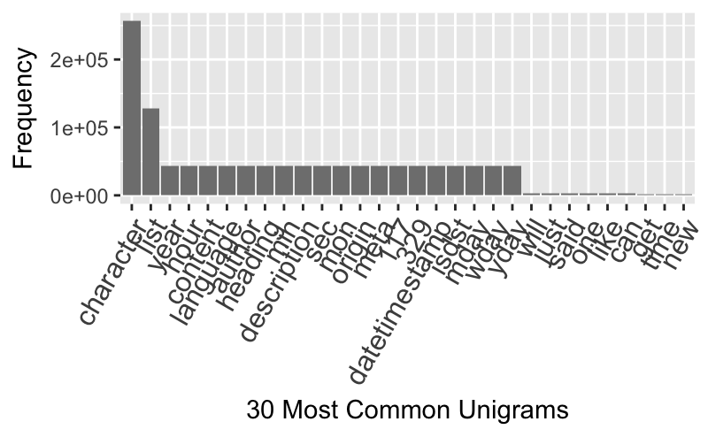

```r
makePlot(freq1, "30 Most Common Unigrams")
```

[figure not shown]

```r
makePlot(freq2, "30 Most Common Bigrams")
```

[output not shown]

[figure not shown]

```r
makePlot(freq3, "30 Most Common Trigrams")
```

[output not shown]

## Prediction Algorithm And Shiny App

The next steps of this capstone project would be to finalize our predictive algorithm, and deploy our algorithm as a Shiny app.

The predictive algorithm will be using n-gram model with frequency lookup similar to the exploratory analysis above. One possible strategy would be to use the trigram model to predict the next word. If no matching trigram can be found, then the algorithm would back off to the bigram model, and then to the unigram model if needed.

The user interface of the Shiny app will consist of a text input box that will allow a user to enter a phrase. Then the app will use our algorithm to suggest the most likely next word after a short delay. The plan is also to allow the user to configure how many words our app should suggest.